# ch3

Chirag Lakhani

April 15, 2015

setwd(“~/Documents/gitProjects/RcodeRegMethBiostat/code”)

This dataset is the Heart and Estrogen/Progestin Study (HERS), a clinical trial of hormone therapy for prevention of recurrent heart attacks and deaths among 2,763 post-menopausal women with existing coronary heart disease.

# Continuous Outcome Variables

## T-test Example

We will first calculate a t-test to compare the difference in glucose levels based on excercise

```r
library(ggplot2)
hersdata <- read.delim("hersdata.txt")
head(hersdata[,c('glucose','exercise')])
```

```
##   glucose exercise
## 1      84       no
## 2     111       no
## 3     114       no
## 4      94       no
## 5     101       no
## 6     116       no
```

```
## stat_bin: binwidth defaulted to range/30. Use 'binwidth = x' to adjust this.
```

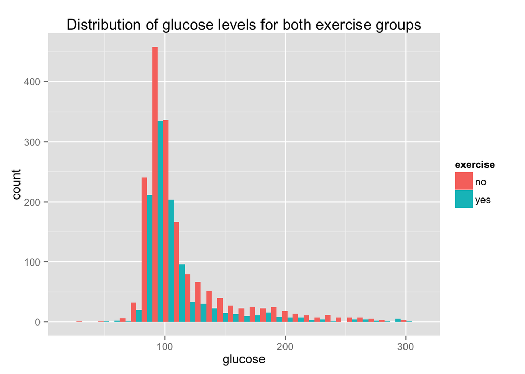

```r
ggplot(hersdata, aes(x=glucose, fill=exercise)) + geom_bar(position="dodge") + ggtitle("Distribution of glucose levels for both exercise groups")
```

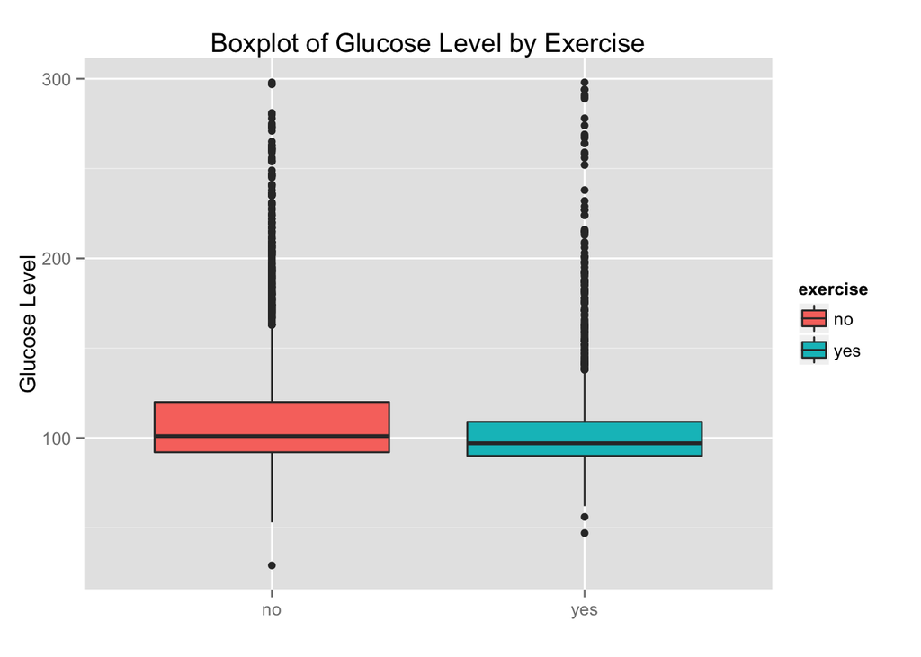

```r
qplot(exercise, glucose, data=hersdata, geom=c("boxplot"),
   fill=exercise, main="Boxplot of Glucose Level by Exercise",
   xlab="", ylab="Glucose Level")
```

Now we will calculate the t-test for average glucose values by exercise

```r
exerciseYes <- hersdata[hersdata$exercise=='yes',]
exerciseNo <- hersdata[hersdata$exercise=='no',]
t.test(exerciseYes$glucose,exerciseNo$glucose)
```

```
##
##  Welch Two Sample t-test
##
## data:  exerciseYes$glucose and exerciseNo$glucose
## t = -4.4423, df = 2431.962, p-value = 9.299e-06
## alternative hypothesis: true difference in means is not equal to 0
## 95 percent confidence interval:
##  -8.984903 -3.481791
## sample estimates:
## mean of x mean of y
##  108.3277  114.5611
```

## ANOVA Example

In this example we will look at the relationship between systolic blood pressure and ethnicity.

```r
library(ggplot2)
hersdata <- read.delim("hersdata.txt")
sbpEthnicity <- hersdata[,c('raceth','SBP')]
tapply(sbpEthnicity$SBP, sbpEthnicity$raceth, mean)
```

```
## African American            Other            White
##         138.2339         135.1809         134.7838
```

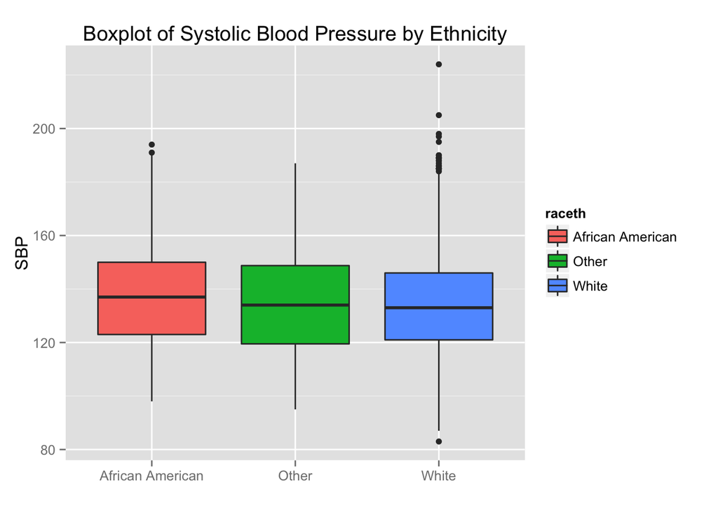

```r
qplot(raceth, SBP, data=sbpEthnicity, geom=c("boxplot"),
   fill=raceth, main="Boxplot of Systolic Blood Pressure by Ethnicity",
   xlab="", ylab="SBP")
```

We see that the mean for African Americans is highest, followed by Other, and lastly White. We will perform an ANOVA test to see if there difference among the three is statistically significant.

```r
attach(sbpEthnicity)
fligner.test(SBP~raceth)
```

```
##
##  Fligner-Killeen test of homogeneity of variances
##
## data:  SBP by raceth
## Fligner-Killeen:med chi-squared = 4.6461, df = 2, p-value =
## 0.09798
```

```r
model <- aov(SBP~raceth)
summary(model)
```

```
##               Df Sum Sq Mean Sq F value Pr(>F)
## raceth         2   2384  1192.1   3.298 0.0371 *
## Residuals   2760 997618   361.5
## ---
## Signif. codes:  0 '***' 0.001 '**' 0.01 '*' 0.05 '.' 0.1 ' ' 1
```

### Multiple Comparisons

It seems that there is some difference in these groups among the three, but we want to know what are those differences. We can do pairwise comparisons of these ethnicities to see which groups are different. We will account for multiple comparisons by using various p-value adjustments such as Bonferroni, Holm, Hochberg, Hommel, etc…

```r
pairwise.t.test(SBP,raceth,p.adjust.method="holm")
```

```
##
##  Pairwise comparisons using t tests with pooled SD
##
## data:  SBP and raceth
##
##       African American Other
## Other 0.386            -
## White 0.031            0.842
##
## P value adjustment method: holm
```

```r
pairwise.t.test(SBP,raceth,p.adjust.method="hochberg")
```

```
##
##  Pairwise comparisons using t tests with pooled SD
##
## data:  SBP and raceth
##
##       African American Other
## Other 0.386            -
## White 0.031            0.842
##
## P value adjustment method: hochberg
```

```r
pairwise.t.test(SBP,raceth,p.adjust.method="bonferroni")
```

```
##
##  Pairwise comparisons using t tests with pooled SD
##
## data:  SBP and raceth
##
##       African American Other
## Other 0.580            -
## White 0.031            1.000
##
## P value adjustment method: bonferroni
```

```r
pairwise.t.test(SBP,raceth,p.adjust.method="hommel")
```

```
##
##  Pairwise comparisons using t tests with pooled SD
##
## data:  SBP and raceth
##
##       African American Other
## Other 0.386            -
## White 0.031            0.842
##
## P value adjustment method: hommel
```

```r
pairwise.t.test(SBP,raceth,p.adjust.method="BH")
```

```
##
##  Pairwise comparisons using t tests with pooled SD
##
## data:  SBP and raceth
##
##       African American Other
## Other 0.290            -
## White 0.031            0.842
##
## P value adjustment method: BH
```

```r
pairwise.t.test(SBP,raceth,p.adjust.method="fdr")
```

```
##
##  Pairwise comparisons using t tests with pooled SD
##
## data:  SBP and raceth
##
##       African American Other
## Other 0.290            -
## White 0.031            0.842
##
## P value adjustment method: fdr
```

All of these methods seem to show is a statistically significant difference in SBP between Whites and African Americans

# Categorical Outcome Variables

## Measures of Risk and Association

### Risk Difference

```r
library(aod)

wcgs <- read.csv("wcgs.csv")
tableComparison <- table(wcgs$arcus,wcgs$chd69)
tableComparison <- tableComparison[,c(2,1)]
prop.test(table(wcgs$arcus,wcgs$chd69))
```

```
##
##  2-sample test for equality of proportions with continuity
##  correction
##
## data:  table(wcgs$arcus, wcgs$chd69)
## X-squared = 13.1161, df = 1, p-value = 0.0002928
## alternative hypothesis: two.sided
## 95 percent confidence interval:
##  0.01593398 0.06245776
## sample estimates:
##    prop 1    prop 2
## 0.9308005 0.8916047
```

```r
tableXtabs <- xtabs(~arcus+chd69,data=wcgs)
prop.test(tableXtabs)
```

```
##
##  2-sample test for equality of proportions with continuity
##  correction
##
## data:  tableXtabs
## X-squared = 13.1161, df = 1, p-value = 0.0002928
## alternative hypothesis: two.sided
## 95 percent confidence interval:
##  0.01593398 0.06245776
## sample estimates:
##    prop 1    prop 2
## 0.9308005 0.8916047
```

### Risk Ratio

```r
library(epitools)
riskratio(tableXtabs, method = c("wald"),conf.level = 0.95,rev = c("neither", "rows", "columns", "both"))
```

```
## $data
##        chd69
## arcus     No Yes Total
##   0     2058 153  2211
##   1      839 102   941
##   Total 2897 255  3152
##
## $measure
##      risk ratio with 95% C.I.
## arcus estimate    lower    upper
##     0 1.000000       NA       NA
##     1 1.566419 1.233865 1.988603
##
## $p.value
##      two-sided
## arcus   midp.exact fisher.exact   chi.square
##     0           NA           NA           NA
##     1 0.0003159313 0.0003407814 0.0002216321
##
## $correction
## [1] FALSE
##
## attr(,"method")
## [1] "Unconditional MLE & normal approximation (Wald) CI"
```

### Odds Ratio

```r
oddsratio(tableXtabs, method = c("wald"),conf.level = 0.95,rev = c("neither", "rows", "columns", "both"))
```

```
## $data
##        chd69
## arcus     No Yes Total
##   0     2058 153  2211
##   1      839 102   941
##   Total 2897 255  3152
##
## $measure
##      odds ratio with 95% C.I.
## arcus estimate lower    upper
##     0  1.00000    NA       NA
##     1  1.63528 1.257 2.127399
##
## $p.value
##      two-sided
## arcus   midp.exact fisher.exact   chi.square
##     0           NA           NA           NA
##     1 0.0003159313 0.0003407814 0.0002216321
##
## $correction
## [1] FALSE
##
## attr(,"method")
## [1] "Unconditional MLE & normal approximation (Wald) CI"
```

### Multiple Predictors

```r
multiPredictors <- xtabs(~agec+chd69,data=wcgs)

prop.test(multiPredictors)
```

```
##
##  5-sample test for equality of proportions without continuity
##  correction
##
## data:  multiPredictors
## X-squared = 46.6534, df = 4, p-value = 1.801e-09
## alternative hypothesis: two.sided
## sample estimates:
##    prop 1    prop 2    prop 3    prop 4    prop 5
## 0.9429098 0.9495875 0.9066667 0.8768939 0.8512397
```

```r
riskratio(multiPredictors, method = c("wald"),conf.level = 0.95,rev = c("neither", "rows", "columns", "both"))
```

```
## $data
##        chd69
## agec      No Yes Total
##   35-40  512  31   543
##   41-45 1036  55  1091
##   46-50  680  70   750
##   51-55  463  65   528
##   56-60  206  36   242
##   Total 2897 257  3154
##
## $measure
##        risk ratio with 95% C.I.
## agec     estimate     lower    upper
##   35-40 1.0000000        NA       NA
##   41-45 0.8830313 0.5755812 1.354708
##   46-50 1.6348387 1.0869527 2.458891
##   51-55 2.1563416 1.4300676 3.251461
##   56-60 2.6057051 1.6520014 4.109984
##
## $p.value
##        two-sided
## agec      midp.exact fisher.exact   chi.square
##   35-40           NA           NA           NA
##   41-45 5.665956e-01 5.587536e-01 5.690688e-01
##   46-50 1.573609e-02 2.049340e-02 1.653286e-02
##   51-55 1.499986e-04 1.631541e-04 1.561175e-04
##   56-60 5.019449e-05 4.717556e-05 2.186623e-05
##
## $correction
## [1] FALSE
##
## attr(,"method")
## [1] "Unconditional MLE & normal approximation (Wald) CI"
```

```r
oddsratio(multiPredictors, method = c("wald"),conf.level = 0.95,rev = c("neither", "rows", "columns", "both"))
```

```
## $data
##        chd69
## agec      No Yes Total
##   35-40  512  31   543
##   41-45 1036  55  1091
##   46-50  680  70   750
##   51-55  463  65   528
##   56-60  206  36   242
##   Total 2897 257  3154
##
## $measure
##        odds ratio with 95% C.I.
## agec     estimate     lower    upper
##   35-40 1.0000000        NA       NA
##   41-45 0.8768215 0.5575563 1.378903
##   46-50 1.7001898 1.0970460 2.634935
##   51-55 2.3186790 1.4845452 3.621494
##   56-60 2.8863138 1.7388945 4.790864
##
## $p.value
##        two-sided
## agec      midp.exact fisher.exact   chi.square
##   35-40           NA           NA           NA
##   41-45 5.665956e-01 5.587536e-01 5.690688e-01
##   46-50 1.573609e-02 2.049340e-02 1.653286e-02
##   51-55 1.499986e-04 1.631541e-04 1.561175e-04
##   56-60 5.019449e-05 4.717556e-05 2.186623e-05
##
## $correction
## [1] FALSE
##
## attr(,"method")
## [1] "Unconditional MLE & normal approximation (Wald) CI"
```

```r
epitab(multiPredictors,method = c("oddsratio", "riskratio", "rateratio"))
```

```
## $tab
##        chd69
## agec      No         p0 Yes        p1 oddsratio     lower    upper
##   35-40  512 0.17673455  31 0.1206226 1.0000000        NA       NA
##   41-45 1036 0.35761132  55 0.2140078 0.8768215 0.5575563 1.378903
##   46-50  680 0.23472558  70 0.2723735 1.7001898 1.0970460 2.634935
##   51-55  463 0.15982050  65 0.2529183 2.3186790 1.4845452 3.621494
##   56-60  206 0.07110804  36 0.1400778 2.8863138 1.7388945 4.790864
##        chd69
## agec         p.value
##   35-40           NA
##   41-45 5.587536e-01
##   46-50 2.049340e-02
##   51-55 1.631541e-04
##   56-60 4.717556e-05
##
## $measure
## [1] "wald"
##
## $conf.level
## [1] 0.95
##
## $pvalue
## [1] "fisher.exact"
```